# Statistical Analysis 4.2: Samples and Populations

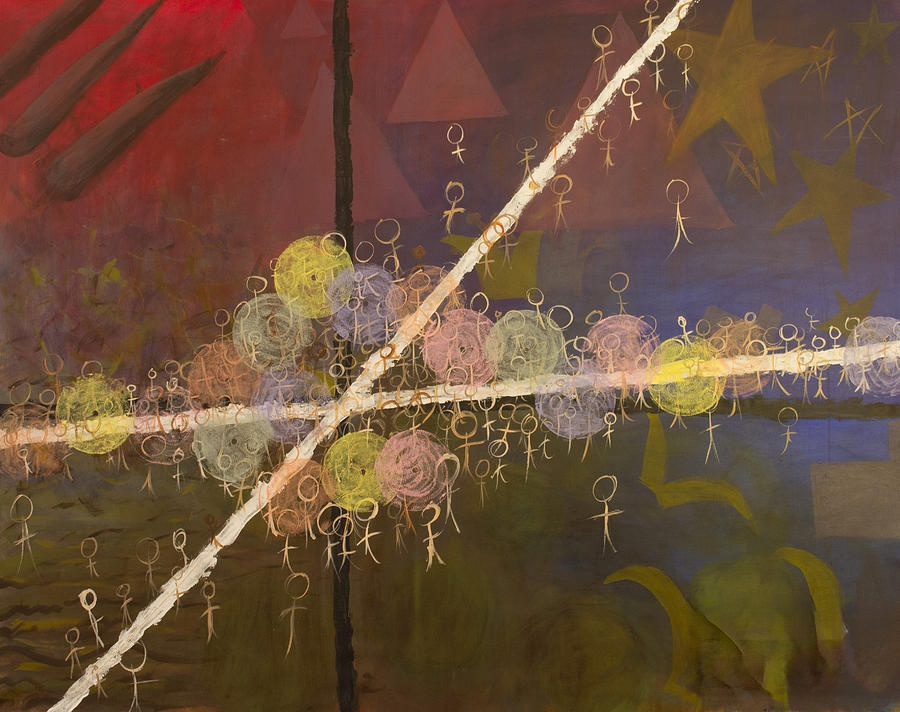

## Samples and Populations

### Overview

This lesson introduces the fundamental concept of sampling.

### Objectives

After completing this module, students should be able to:

1. Make inferences from sample means to population means.
2. Explain how the Central Limit Theorem allows us to use the normal distribution in most cases.
3. Calculate standard errors and distinguish them from standard deviations.
4. Calculate confidence intervals from sample statistics.

### Readings

Schumacker, Ch 4-6. Lander, 15.1.

### What is sampling?

**Sampling** is the process whereby we collect and analyze data for a subset in a population. For instance, the total population of the US is about ~328 millions; but when we want to know what politician is ahead on a race we don’t ask the entire population for their opinion. Instead we rely on a poll that is based on a *sample* of the population. The greater number of individuals we include in the sample, then the more likely it is that we get a good approximation to the actual state of the race.

**Random sampling** is the process of selecting individuals to be included in the sample in a way that is independent with respect to any relevant variable in the study. Think about the poll example again, do you think the results of the poll will depend on the neiborhood that we select to conduct the sample? what about the time of the day? what if we only contact potential voters via landlines? you can see that any of those factors can alter the results that we get. In that case we say that the sample is non-random, as the charactersitics of the individuals selected are not independent of the: neiborhood, time of day, medium, etc. It is important for us to distinguish between actual random variation in the data than variation caused by the way individuals are selected in the sample.

When sampling, the sample average will generally not be exactly equal to the mean of the population distribution. If we collect several random samples, then we should expect the sample average to randomly fluctuate around the population mean. If there is a systematic difference between the population mean and the samples we are collecting, then we say that the sample average is *biased* and this is probably the result of non-random sampling.

For example, imagine that you were really invested in last year’s presidential election and as a result decided to start conducting your own polls. Because you have limited resources and time you used the internet to collect your data. After several polls you conclude that the democratic candidate (Joe Biden) was going to win the popular vote by a 10% margin. Weeks after weeks you got values around that 10%: 7%, 15%, 9%, 10.25%, etc. You felt confident because you are not rellying only on one sample, but a large collection of them. Then, the results came in and you see that the actual margin was about 5%. What when wrong? Well, conducting the survey over the internet probably over-represented the younger population, which actually voted around that margin in favor of the democratic candidate. We must then be careful in relying on results that are based on non-random sample, even if conducted repeatedly.

## Samples and Populations

One of the most fundamental goals in statistics is to make claims about unknown populations using smaller samples from those populations. We are forced to collect samples because:

- It is practically impossible to obtain a full and complete list of all members of a population.
- Collecting data for an entire population would be expensive.
- Even if it were possible, collecting data for an entire population is time consuming.
- Even if we had the time to collect the data. The data may be to large and impose a great processing power burden.

### A note on notation :)

In case you were confused, we’ll follow this notation to distinguish the sample average or standard deviation from the population mean or standard deviation.

| True value (in Greek) | Sample (latin script) |
| --- | --- |
| $\mu$, the population mean | $\bar{x}$, the sample average |
| $\sigma$, the population standard deviation : | $s$ (somtimes $sd$), the mean standard deviation : |

Then, when talking about the average height of the typical american men we’ll use $\mu_{men}$. But when talking about the average that we obtained from a sample of 3,000 men we’ll use $\bar{x}_{men}$.

If the sample that was used to calculate $\bar{x}_{men}$ was random then we should expect that the difference between $\mu_{men}$ and $\bar{x}_{men}$ to be equal to zero. If the sample was non-random then some systematic discrepancy may be introduced. For instance, if we collected a sample of athletes we’ll have get positive bias $\bar{x}_{men} > \mu_{men}$.

### Calculating Sample and Population Statistics

**Population mean** :

The population mean is calculated as:

$$\mu = \dfrac{1}{N}\sum_{i=1}^{N} x_i$$

Where $N$ is the entire population and $x_{i}$ is an individual observation.

**Sample average**:

The sample average is calculated as:

$$\bar{x} = \dfrac{1}{n}\sum_{i=1}^{n} x_i$$
Where $n$ is the sample size.

**Standard deviation** :

The standard deviation of the population can be calculated as:

$$\sigma = \sqrt{\frac{1}{N} \sum_{i=1}^N (x_i - \mu)^2}$$

Note how when observations are typically away from the mean (either too large or too small) the term $(x_i - \mu)^2$ makes $\sigma$ larger. This is what makes the standard deviation an indicator of dispersion. Finally, note that if $x_{i} = \mu$ for all observations as in the case of a constant variable, then $\sigma = 0$.

Finally, note that after we calculate the squared differences $(x_i - \mu)^2$, we must add them and divide by $N$. Then, the standard deviation is an average on itself. It is the average of the squared differences of a variable. As such, it represents the *average/typical* deviation from the mean.

**Sample Standard Deviation**

$$s = \sqrt{\frac{1}{n-1} \sum_{i=1}^n (x_i - \bar{x})^2}$$

A couple of differences this time in relation to the previous formula. First, it uses $\bar{x}$ instead of $\mu$ and then, the squared deviations from the means are divided by $n-1$ instead of $N$. The reason for this is that we loose one *degree of freedom* when we calulcate $\mu$, then it is as if we are working with $n-1$ observations instead of $n$ when calculating $s$. To make this point more clear, think of the following extreme scenario: the population for $x$ is $\{1,2,3,...,1000\}$. The numbers from 1 to 1000.

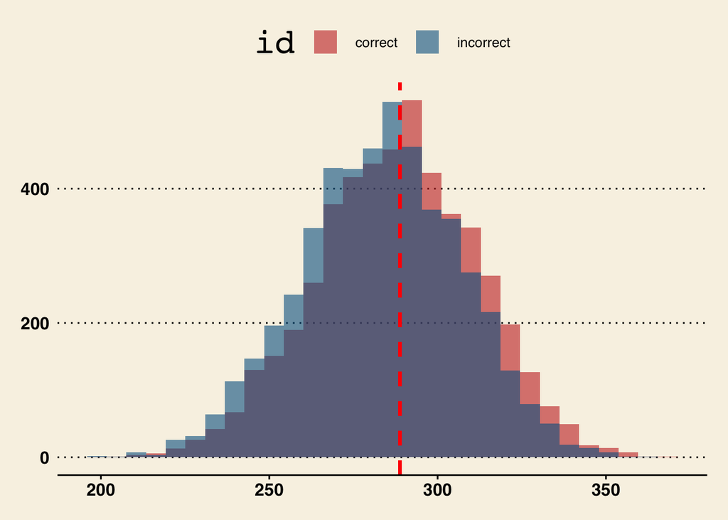

```r
k <- 5000 # Number of simulations
n <- 30
x_bar <- rep(NA, k)
s_correct <- rep(NA,k)
s_incorrect <- rep(NA,k)
population <- 1:1000

for(i in 1:k) {
  x_sample <- sample(population,n)
  x_bar[i] <- mean(x_sample)
  s_correct[i] <- sqrt((1/(n-1))*sum((x_sample - x_bar[i])^2))
  s_incorrect[i] <- sqrt((1/n)*sum((x_sample - x_bar[i])^2))
}

# Now let's produce the histogram of the distributions of the standard deviations with the real standard deviation as a vertical line:
library(ggplot2)
library(ggthemes)

ggplot(data = data.frame(x = c(s_correct, s_incorrect),
                         id = c(rep("correct",k), rep("incorrect", k)), stringsAsFactors = T), aes(x=x, fill = id)) + geom_histogram( alpha=0.6, position = 'identity') + geom_vline(xintercept= sd(population), size = 1.2, color = "red", linetype = "dashed") + theme_wsj() + scale_fill_wsj()
```

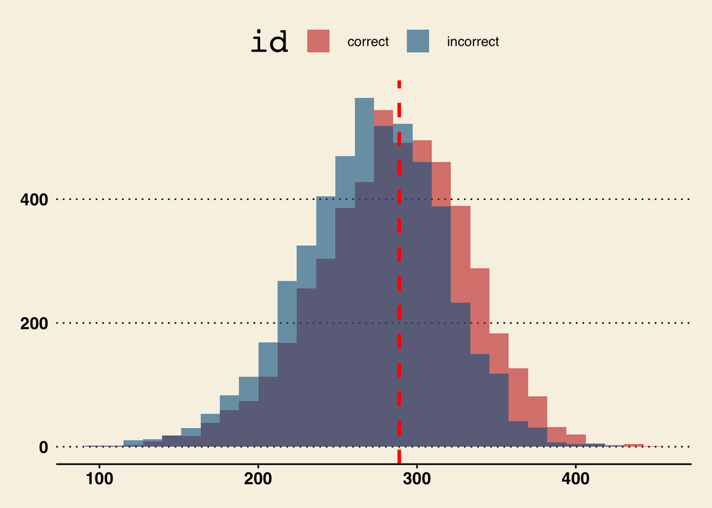

```r
k <- 5000 # Number of simulations
n <- 10
x_bar <- rep(NA, k)
s_correct <- rep(NA,k)
s_incorrect <- rep(NA,k)
population <- 1:1000

for(i in 1:k) {
  x_sample <- sample(population,n)
  x_bar[i] <- mean(x_sample)
  s_correct[i] <- sqrt((1/(n-1))*sum((x_sample - x_bar[i])^2))
  s_incorrect[i] <- sqrt((1/n)*sum((x_sample - x_bar[i])^2))
}

# Now let's produce the histogram of the distributions of the standard deviations with the real standard deviation as a vertical line:
ggplot(data = data.frame(x = c(s_correct, s_incorrect),
                         id = c(rep("correct",k), rep("incorrect", k)), stringsAsFactors = T), aes(x=x, fill = id)) + geom_histogram( alpha=0.6, position = 'identity') + geom_vline(xintercept= sd(population), size = 1.2, color = "red", linetype = "dashed") + theme_wsj() + scale_fill_wsj()
```

## The Central Limit Theorem

**How sure can we be about our sample means?**

The **central limit theorem** is the answer:

If we were to take a very large number of samples of size $n$ from any population, and then create a distribution of a population characteristic of interest, say the mean or the standard deviation, the resulting distribution is called a **sampling distribution**. That’s what you saw in the previous histogram, the sampling distributions of the sample standard deviation calculated correctly and incorrectly.

The **central limit theorem**, which we are not going to provide a formal proof here [https://en.wikipedia.org/wiki/Central_limit_theorem], states that when we add random variables that are independent the resulting distribution converges in probability to the normal distribution. Even if the original variables are not normal themselves. This is a very powerful theorem, and the basis of most statistical applications. It imposes the following properties on sampling distributions (I’ll provide a graphical argument for each point as illustration):

**Features of the sampling distribution derived from the Central Limit Theorem:**

- **Equal average**: The average of the sampling distribution approximates the true population mean, provided that the sample is random.

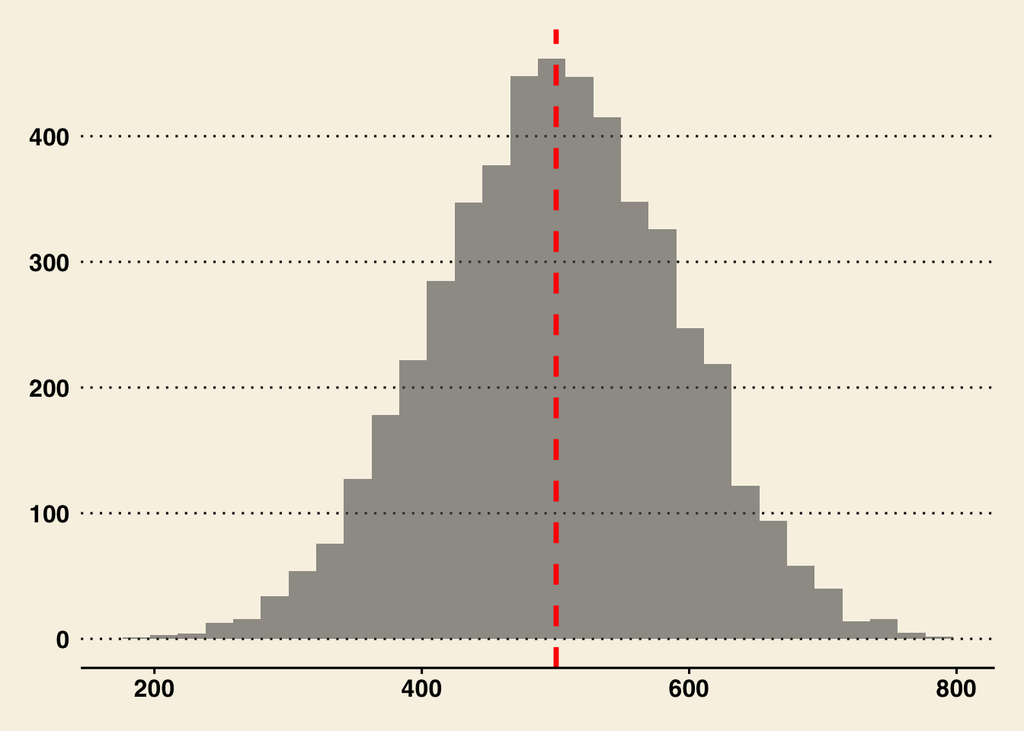

```r
k <- 5000 # Number of simulations
n <- 10
x_bar <- rep(NA, k)
population <- 1:1000

for(i in 1:k) {
  x_sample <- sample(population,n)
  x_bar[i] <- mean(x_sample)
}

# Now let's produce the histogram of the sample average and the population average
ggplot(data = data.frame(x = x_bar), aes(x=x)) + geom_histogram( alpha=0.6, position = 'identity') + geom_vline(xintercept= mean(population), size = 1.2, color = "red", linetype = "dashed") + theme_wsj() + scale_fill_wsj()
```

- **Unbiasedness**: Provided that the sample is a random sample. The difference between the population parameter and the calculated parameter from the sample (these differences are called the standard errors) will be equal to zero on average. Moreover, due to the fact that the normal distribution is symmetric, the errors will be symmetrically distributed around zero (half of the observations to the left, half of the observations to the right).

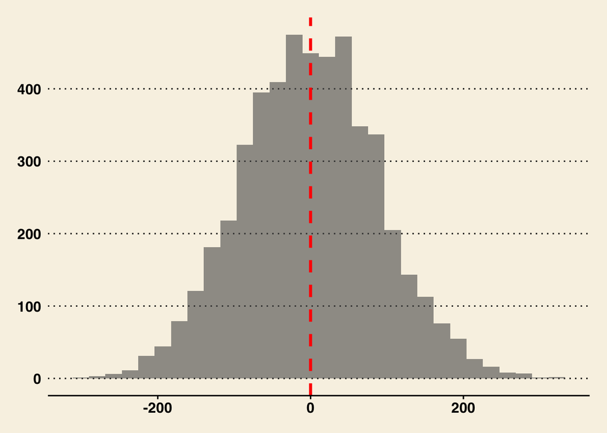

```r
k <- 5000 # Number of simulations
n <- 10
x_bar <- rep(NA, k)
errors <- rep(NA, k)
population <- 1:1000
mu <- mean(population)

for(i in 1:k) {
  x_sample <- sample(population,n)
  x_bar[i] <- mean(x_sample)
  errors[i] <- x_bar[i] - mu
}

# Now let's produce the histogram of the error terms
ggplot(data = data.frame(x = errors), aes(x=x)) + geom_histogram( alpha=0.6, position = 'identity') + geom_vline(xintercept= 0, size = 1.2, color = "red", linetype = "dashed") + theme_wsj() + scale_fill_wsj()
```

- The standard deviation of the sampling distribution is the **standard error**.
- The larger the sample size ($n$), the larger the denominator of the standard error (recall the formula for the sample standard deviation). This is the property that allows a sample estimation of a population parameter to converge to the true parameter as the sample size increase. In other words, the sample distribution collapses on the true value as the sample size increase.

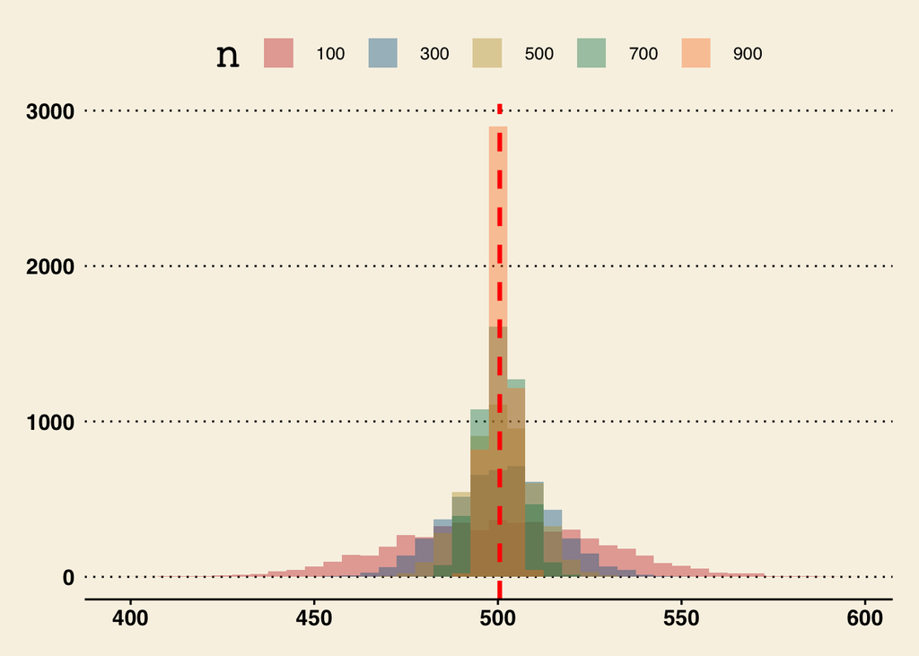

```r
k <- 5000 # Number of simulations
n <- seq(100,1000,200)
x_bars <- NULL

population <- 1:1000
mu <- mean(population)
x_bars <- rep(NA, k*length(n))
for(j in n) {
  for(i in 1:k) {
    x_sample <- sample(population,j)
    x_bar[i] <- mean(x_sample)
  }
  x_bars <- c(x_bars,x_bar)
}

# Now let's produce the histogram of the error terms
ggplot(data = data.frame(x = x_bars,
                         n = as.factor(rep(n, each = k))), aes(x=x, fill = n)) + geom_histogram(binwidth = 5 ,alpha=0.4, position = 'identity') + geom_vline(xintercept= mu, size = 1.2, color = "red", linetype = "dashed") + theme_wsj() + scale_fill_wsj()
```

### The standard error

To calculate the standard error of a sample we use the following formula:

$$se = \frac{s}{\sqrt{n}}$$

Remember that $s$ is the standard deviation of the sample, $n$ is the size of the sample, and $se$ is a measure of the spread of $\bar{x}$’s around the truth $\mu$ – which we call the “standard error”.

Just as we saw in the previous set of histograms, the error in $\bar{x}$ in estimating $\mu$ goes down with increasing $n$ – the bigger the $n$, the bigger the denominator and the smaller $se$ is – ie, those $\bar{x}$ cluster more tightly aroung $\mu$.

### From uncertainty about $\bar{x}$ to uncertainty about $\mu$

To know how certain, or rather uncertain, we can be about the proximity of the sample average to the population mean, we use **confidence intervals**. A confidence interval establishes a “margin of error” around the sample average that states the likelihood that the population mean is included in the interval. Commonly used confidence intervals are 90%, 95% or 99%. In the following slides we’ll go deeper into the concept of confidence intervals and how, thanks to the central limit theorem, we can use the normal distribution to calculate them.

## Confidence Intervals

A confidence interval is calculated in general as follows:

$$Pr(\bar{x} - CDF^{-1}(1-\dfrac{\alpha}{2})se \leq x \leq \bar{x} + CDF^{-1}(\dfrac{\alpha}{2}) se )$$

Where $\mu$ is the population mean, $se$ is the standard error, and $CDF^{-1}()$ is the inverse of a cumulative density function (e.g. the z-table that returns z-scores using probabilities as inputs or the `qnorm` function in R) and $100(1-\alpha)\%$ is the confidence level of the confidence interval.

For instance, if I say that the population mean is inside the confidence interval with a confidence level of $95\%$ then $\alpha$ is equal to $0.05$. Then, to construct the confidence interval we need to find the value of $CDF^{-1}(0.025)$ and $CDF^{-1}(0.0975)$, which, under the assumption that the sampling distribution follows a normal distribution as the Central Limit Theorem states, we can get the inverse CDF value using R or the z-table:

```r
# For upper limit
qnorm(0.025, 0, 1)
```

```
## [1] -1.959964
```

```r
# For lower limit
qnorm(0.975, 0, 1)
```

```
## [1] 1.959964
```

Or about -1.96 and 1.96. Then, the confidence interval becomes:

$$Pr(\bar{x} - 1.96se \leq x \leq \bar{x} + 1.96 se )$$

$$(6.08, 13.92)$$

Which means that the there is a 95% confidence level that the population mean is somewhere between 6.08 and 13.92.

But…there is a catch. The Central Limit Theorem can only be safely applied when the sample size is *large*.

**When the sample is large enough (n>30), we calculate confidence intervals as previously described:**

For a 95% confidence interval:

$$P(\bar{x} - 1.96 se \leq \bar{x} \leq \bar{x} + 1.96 se) \approx 0.95$$
and for a 99% confidence interval:

$$P(\bar{x} - 2.58 se \leq \mu \leq \bar{x} + 2.58 se) \approx 0.99$$

Make sure that you know where the $2.58$ came from.

The reason for this is that when the sample size is very small, the assumption of convergence in probabilities that is required from the central limit theorem cannot be applied. Instead, a very close approximation is to use the student-t inverse CDF when calculating the limits of the confidence interval. Recall that the student-t distribtion is described by a parameter called $d.f.$ (degrees of freedom) which is equal to $n-1$ when calculating an average. As a result, the limits of the confidence interval based on the student-t distribution change with the sample size.

For example, this is the confidence interval using a confidence level of 95% and $n=30$:

```r
qt(0.025, 29)
```

```
## [1] -2.04523
```

```r
qt(0.975, 29)
```

```
## [1] 2.04523
```

$$P(\bar{x} - 2.04523 se \leq \bar{x} \leq \bar{x} + 2.04523 se) \approx 0.95$$

Compared to the same confidence interval with $n=15$.

```r
qt(0.025, 14)
```

```
## [1] -2.144787
```

```r
qt(0.975, 14)
```

```
## [1] 2.144787
```

$$P(\bar{x} - 2.144787 se \leq \bar{x} \leq \bar{x} + 2.144787 se) \approx 0.95$$

As you can see, the reduction of the sample size makes the confidence intervals wider. The increase in $se$ will also make them even wider.

### Example 1

Example 1. How about we randomly sample 150 cities in the U.S. and calculate the average number of violent crimes in these cities is 4.1 per 100,000. We know that:

$$\begin{eqnarray*}
$\bar{x}$ & = & 4.1 \\
n & = & 150 \\
sd & = & 3.8
\end{eqnarray*}$$

Let’s enter that data in R:

```r
x_bar <- 4.1
n <- 150
sd <- 3.8
```

We can calculate the standard error through:

$$se = \frac{s}{\sqrt{n}}$$

```r
se <- sd/sqrt(n)
se
```

```
## [1] 0.3102687
```

And we know we can calculate the 95% CI’s through:

$$CI_.95 = \bar{x} \pm 1.96 se$$

```r
ci <- c(x_bar - 1.96*se, x_bar + 1.96*se)
ci
```

```
## [1] 3.491873 4.708127
```

What do these values tell us? Make sure you know how to answer this.

We can repeat the excercise assuming a confidence level of 99%:

$$P(\bar{x} - 2.58 se \leq \mu \leq \bar{x} + 2.58 se) \approx 0.99$$

```r
ci <- c(x_bar - 2.58*se, x_bar + 2.58*se)
ci
```

```
## [1] 3.299507 4.900493
```

### Example 2

Example 2. Say you wanted to have a 95% CI that was much tighter, eg, plus or minus .1 crimes. How many more cities would you have to include in your sample assuming the sample mean (4.1) and sample standard deviation (3.8) stayed the same?

### Example 3a (long)

Example 3a. The General Social Survey asks a sample of individuals from the US how many hours of TV they watch. There are 899 respondents, with a mean response of 2.865 hours, and a standard deviation of 2.617. From these data alone we can now make statements about the population of the entire country (presuming the sample was truly random).

If our best guess about the US mean number of hours watched is $\bar{x} = 2.865$, what can we say about how accurate that guess is? Well, we know that $P(\bar{x} - 1.96 se \leq \mu \leq \bar{x} + 1.96 se) \approx 0.95$, so our 95% *confidence interval* (CI) is

$$CI_{0.95} = [2.865-1.96*2.617/\sqrt{899},2.865+1.96*2.617/\sqrt{899}] = [2.694,3.036]$$

i.e., the true population mean $\mu$ is between 2.694 and 3.036 with 95% confidence level.

### Example 3b (long)

Example 3b. Returning to our original GSS survey about numbers of hours of watching tv, how certain are we that the total number of hours watched is less than 3?

Well, the standard error is $2.617/ \sqrt{899} = 0.087$. So we can just plug this into the normal distribution (or better, use R) to figure it out.

- To figure it out by hand, we would ask how far, in standard errors, 3 is from the mean: $(3-2.865)/0.087 = 1.55$.
- Then we would look up in our Z (normal) distribution table 1.55, to see what proportion of a normal population is below $\mu + 1.55$. Or we could just use R: `pnorm(3, 2.865,0.087) = 0.94`. That is, we are 94% confident that the total is less than 3 hours.
- Remember that the 95% CI was $[2.694,3.036]$. If we plug $3.036$ into `pnorm`, we get `pnorm(3.036, 2.865,0.087) = 0.975`. That’s not 95 though – what’s going on? Remember that the 95% CI contains 95% of the observations, but is symmetrical, which means that 2.5% of the observations are not included on the right, and 2.5% of the observations are not included on the left. That is, the right bound of the 95% CI is at the 97.5 percentile mark, and the left bound is at the 2.5 percentile mark (97.5 - 2.5 = 95).